# SMO

Practical Assignment: Support Vector Machines

Métodos Avanzados en Aprendizaje Automático

Carlos María Alaíz Gudín - Universidad Autónoma de Madrid

Francisco Javier Sáez Maldonado - José Antonio Álvarez Ocete

**Initial Configuration**

This cell defines the configuration of Jupyter Notebooks.

```python
%%html
<head><link rel="stylesheet" href="style.css"></head>
```

```python
%matplotlib inline
%load_ext autoreload
%autoreload 2
```

```
The autoreload extension is already loaded. To reload it, use:
  %reload_ext autoreload
```

This cell imports the packages to be used (all of them quite standard except for `Utils`, which is provided with the notebook).

```python
import numpy as np

import matplotlib
import matplotlib.pyplot as plt

from Utils import plot_dataset_clas, plot_svc, plot_svc_animation_frame

matplotlib.rc('figure', figsize=(15, 5))
seed = 123
```

# Introduction

This practical assignment consists in implementing a simplified version of the SVC class of `sklearn`.

This class will contain two fundamentals routines, one for training a non-linear SVC (using the RBF kernel), based on the SMO algorithm for solving the dual optimization problem, and the other one for predicting over new out-of-sample points.

# SMO Algorithm

## Optimization Problem

The dual optimization problem for the Soft-Margin SVM is: $$ \left \{ \begin{array}{l} \min_{\boldsymbol{\alpha} \in \mathbb{R}^N} \frac{1}{2} \boldsymbol{\alpha}^\intercal \tilde{\mathbf{K}} \boldsymbol{\alpha} - \boldsymbol{\alpha}^\intercal \mathbf{1} \\ \text{ s.t. } \boldsymbol{\alpha}^\intercal \mathbf{y} = 0 , 0 \le \boldsymbol{\alpha} \le C , \end{array} \right . $$ where $\tilde{k}_{ij} = y_i y_j \mathcal{K}(\mathbf{x}_i, \mathbf{x}_j)$.

This optimization problem is a QP problem, which is usually solved using an *ad hoc* algorithm: Sequential Minimal Optimization (SMO).

## SMO and Coordinate Descent

The main idea behind SMO is that the optimization problem is too involved to be solved as a whole, but it can be largely simplified considering only a few variables at a time. In this divide-and-conquer approach, called coordinate descent, the objective function is iteratively minimized over the different variables.

In particular, SMO deals with two variables, the smaller working group that can be modified while respecting the constraints. Formally, the algorithm updates the current $\alpha^\text{old}_i$ and $\alpha^\text{old}_j$ coefficients to some new values $\alpha_i$ and $\alpha_j$, assuming that $\boldsymbol{\alpha}^\text{old}$ satisfies $(\boldsymbol{\alpha}^\text{old})^\intercal \mathbf{y} = 0$. In order to keep respecting the constraint in the new estimation, the following equation needs to be fulfilled: \begin{align*} & y_i \alpha^\text{old}_i + y_j \alpha^\text{old}_j = y_i \alpha_i + y_j \alpha_j \\ &\implies y_i (\alpha_i - \alpha^\text{old}_i) = - y_j (\alpha_j - \alpha^\text{old}_j) \\ &\implies \alpha_i = \alpha^\text{old}_i - y_i y_j (\alpha_j - \alpha^\text{old}_j) . \end{align*}

For simplicity, one can assume that the update for the $j$-th coefficient is given by $\alpha_j = \alpha^\text{old}_j + d$, and hence the optimization problem becomes a simple one-dimensional minimization. Therefore, it can be solved by computing the derivative with respect to $d$ and equating to $0$. After some derivations, the optimum unconstrained update turns out to be:

\begin{align*} d &= \frac{y_j (E(\mathbf{x}_j, y_j) - E(\mathbf{x}_i, y_i))}{\kappa} , \text{ where} \\ \kappa &= 2 \mathcal{K}(\mathbf{x}_i, \mathbf{x}_j) - \mathcal{K}(\mathbf{x}_i, \mathbf{x}_i) - \mathcal{K}(\mathbf{x}_j, \mathbf{x}_j) , \text{ and} \\ E(\mathbf{x}, y) &= \sum_{i = 1}^N \alpha^\text{old}_i y_i \mathcal{K}(\mathbf{x}_i, \mathbf{x}) - y . \end{align*}

## Clipping

The previous update does not take into account the box constrains $0 \le \alpha_i, \alpha_j \le C$. In order to satisfy these constraints for both $\alpha_i$ and $\alpha_j$, $\alpha_j$ has to be clipped to the interval $[L, H]$, where $$ \begin{cases} L = \max(0, \alpha^\text{old}_j - \alpha^\text{old}_i), & H = \min(C, C - \alpha^\text{old}_i + \alpha^\text{old}_j) & \text{if } y_i \neq y_j , \\ L = \max(0, \alpha^\text{old}_j + \alpha^\text{old}_i - C), & H = \min(C, \alpha^\text{old}_i + \alpha^\text{old}_j) & \text{if } y_i = y_j . \end{cases} $$

Therefore, the update for $\alpha_j$ becomes: $$ \alpha_j = \min(\max(\alpha^\text{old}_j + d, L), H) , $$ and, as mentioned above, the corresponding update for $\alpha_i$ is: $$ \alpha_i = \alpha^\text{old}_i - y_i y_j (\alpha_j - \alpha^\text{old}_j) . $$

## Selecting the Working Pair

There are different methods for selecting the working pair of coefficients $(i, j)$ that will be updated. Usually, first or second order information is used to choose the working set, trying to find those that will provide the largest minimization of the objective function.

Nevertheless, in this work a simplified version of SMO will be implemented. The first coefficient $i$ will be selected just iteratively, cycling over all the possible values $i = 1, 2, \dotsc, N$. The second coefficient $j$ is selected randomly over the remaining possible values $j \neq i$.

It should be noted that this approach will not guarantee the convergence in general, since not all possible pairs $(i, j)$ are explored, but it will work in most problems.

## Stopping Criteria

The algorithm will be terminated when a certain maximum number of iteration is reached (for each iteration, all the coefficients are updated), or when after one iteration the total change of the coefficients is smaller than a certain tolerance, $\| \boldsymbol{\alpha} - \boldsymbol{\alpha}^\text{old}\| < \epsilon$.

Since the working pair is generated randomly, it can happen that after a whole iteration the changes are smaller than $\epsilon$ not because the optimization is finished, but because of "bad luck". A workaround is to set $\epsilon = 0$ to force all the iterations.

## Computing the Intercept

Once the optimum dual coefficients $\boldsymbol{\alpha}^*$ have been estimated, the intercept $b^*$ can be computed knowing that any support vector $\mathbf{x}_k$ with $0 < \alpha^*_k < C$ satisfies: $$ b^* = y_k - \sum_{i = 1}^N \alpha^*_i y_i \mathcal{K}(\mathbf{x}_i, \mathbf{x}_k) . $$

This equality is usually averaged over all the possible vectors $k$ satisfying $0 < \alpha^*_k < C$ for reasons of numerical stability.

## Prediction

Once the model is trained and the optimal parameters $\boldsymbol{\alpha}^*$ and $b^*$ are known, the score predicted over a new sample $\mathbf{x}$ is: $$ f(\mathbf{x}) = \sum_{i = 1}^N \alpha^*_i y_i \mathcal{K}(\mathbf{x}_i, \mathbf{x}) + b . $$

Finally, the class is assigned with: $$ \hat{y} = \operatorname{sign}(f(\mathbf{x})) . $$

# Implementation of the SVC

## Requirements

The objective of this assignment is to complete the class `MySVC` sketched below, which should contain at least the following methods.

```
__init__(self, C=1.0, gamma="scale", tol=0.0001, max_iter=10000)
```

- This is the construction method for the class, with the following parameters:
  - `C`: Regularization parameter $C$ of the SVC.
  - `gamma`: Kernel parameter $\gamma$ of the RBF kernel.
  - `tol`: Tolerance for the stopping criterion $\epsilon$.
  - `max_iter`: Maximum number of iterations (in the sense of epochs, each iteration contains a pass through all the coefficients).
- This method should only store the parameters in fields of the class, to be used when needed.

```
fit(self, X, y)
```

- This is the training method, with the following parameters:
  - `X`: Training data matrix $\mathbf{X} \in \mathbb{R}^{N \times d}$.
  - `y`: Vector of labels $\mathbf{y}$, with $y_i \in \{-1, +1\}$.
- This method should solve the dual optimization problem, storing the obtained coefficients and other useful information in fields of the class.

```
decision_function(self, X)
```

- This is the method that computes the output of the SVC, with the following parameters:
  - `X`: Test data matrix $\mathbf{X}' \in \mathbb{R}^{N' \times d}$.
- This method should predict the output (the score) of the SVC, using the information stored in the fields of the class, and return it as a vector

```
predict(self, X)
```

- This is the method that computes the predicted class of the SVC, with the following parameters:
  - `X`: Test data matrix $\mathbf{X}' \in \mathbb{R}^{N' \times d}$.
- This method should predict the assigned class of the SVC, using the information stored in the fields of the class, and return it as a vector.

## Recommendations

Additional auxiliary methods can be defined to simplify the code. Some suggestions are:

1. A method to compute the output of the SVC, with the current estimated parameters but without considering the intercept: $$ \sum_{i = 1}^N \alpha_i y_i \mathcal{K}(\mathbf{x}_i, \mathbf{x}) . $$
2. A method to compute $E(\mathbf{x}, y)$.
3. A method to compute the lower and upper bounds $L$ and $H$ for the clipping of the update.
4. A method to estimate $b^*$.

## Implementation

* Complete the `MySVC` class below, satisfying the described requirements.

```python
import numpy as np
from sklearn.metrics.pairwise import rbf_kernel, linear_kernel
from numpy.linalg import norm

class MySVC():
    """
    Implementation of SVC that uses SMO as the QP-solver.
    """
    def __init__(self, C=1.0, gamma="scale", tol=0.0001, max_iter=100, kernel='rbf'):
        """
            Initialization of the SVC.
            - C: regularization constant
            - gamma:
        """
        self.C = C
        self.tol = tol
        self.max_iter = max_iter
        self.kernel = kernel

        if gamma != 'scale' and gamma != 'auto':
             raise AttributeError('Not valid gamma: {}'.format(self.gamma))
        self.gamma = gamma

        # Assign the kernel function
        if self.kernel == 'rbf':
            self.kernel_ = lambda X, Y : rbf_kernel(X, Y)
        elif self.kernel == 'linear':
            self.kernel_ = lambda X, Y: linear_kernel(X, Y)
        elif callable(kernel):
            self.kernel_ = kernel
        else:
            raise AttributeError('Not valid kernel type: {}'.format(self.kernel))

    def fit(self, X, y):
        """
            Fits the model to the given data using the SMO algorithm
            - x: attributes
            - y: class labels
        """
        # Constants
        N = X.shape[0]

        # Options for gamma (for compatibility with sklean).
        if (self.gamma == "scale"):
            self.gamma = 1.0 / (N * X.var())
        elif (self.gamma == "auto"):
            self.gamma = 1.0 / N
        else:
            raise ValueError('Not valid gamma: {}'.format(self.gamma))

        # Initialization of the dual coefficients (named "a" instead of "alpha" for simplicity).
        self.a = np.zeros(N)

        # Other initializations.
        K = self.kernel_(X, X)

        # Loop over the iterations.
        for it in range(self.max_iter):
            # Initializations.
            a_old = self.a.copy()
            i_indexes = np.arange(N)
            j_indexes = [ np.random.choice(i_indexes[i_indexes != i])
                            for i in i_indexes ]

            # Loop over the coefficients.
            for i,j in zip(i_indexes, j_indexes):
                L, H = self._compute_bounds(y, i, j)

                # Update of the corresponding a[i] and a[j] values
                aj_old = self.a[j].copy()
                self.a[j] = np.minimum(np.maximum(self.a[j] + self._d(X, y, i, j, K), L), H)
                self.a[i] = self.a[i] - y[i]*y[j]*(self.a[j] - aj_old)

            # Check of the stopping conditions.
            if norm(a_old - self.a) < self.tol:
                break

        # Storage of the obtained parameters and computation of the intercept.
        self.support_ = np.where(self.a > 0)[0]
        self.support_vectors_ = X[self.support_]
        self.intercept_ = self._compute_intercept(K, y)
        self.coef_ = None
        self.dual_coef_ = (y * self.a)[self.support_]

        # In the linear case we can recover the weights 'w' of the primal solution
        if self.kernel == 'linear':
            self.coef_ = ((self.a * y) @ X).reshape(1, -1) # Reshape for compatibility with Sklearn

        return self

    def decision_function(self, X):
        """
            Computes the decision function for a given vector X
            - X: NxM dimensional array, where N is the number of examples and
                 M is the number of features
        """
        return np.dot(self.dual_coef_,
                      self.kernel_(self.support_vectors_, X)) \
                        + self.intercept_

    def predict(self, X):
        """
            Computes the prediction for a given vector X
            - X: NxM dimensional array, where N is the number of examples and
                 M is the number of features
        """
        return np.sign(self.decision_function(X))

    # Auxiliary methods.

    def _compute_bounds(self, y, i, j):
        """
            Computes the bounds that alpha[j] must satisfy in the QP problem
            - y: class labels
            - i: i-th position of the dual coefficients
            - j: j-th position of the dual coefficients
        """
        if y[i] != y[j]:
            L = np.maximum(0, self.a[j] - self.a[i])
            H = np.minimum(self.C, self.C - self.a[i] + self.a[j])
        else:
            L = np.maximum(0, self.a[j] + self.a[i] - self.C)
            H = np.minimum(self.C, self.a[i] + self.a[j])
        return L,H

    def _d(self, X, y, i, j, K):
        """
            Computes the amount of change that the coefficient j changes
            - X: Input population, vector of size NxM
            - y: labels of the population X
            - i: i-th position of the dual coefficients
            - j: j-th position of the dual coefficients
            - K:
        """
        k = 2*K[i,j] - K[i,i] - K[j,j]
        if k == 0:
            raise ValueError('Cannot compute d with k = 0 for (i={},j={})'.format(i,j))
        return y[j] * (self._E(K, y, j) - self._E(K, y, i)) / k

    def _E(self, K, y, i):
        """
            Computes the error
        """
        # Computes E for the expression of d
        return self._compute_output(K, y, self.a, i) - y[i]

    def _compute_output(self, K, y, a, i):
        """
            A method to compute the output of the i-th element with the given alpha
            wihtout considering the intercept.
            - K: matrix that contains all the possible products of the kernel
            - y: labels of the data
            - a: dual coeficcients
            - i: i-th position used in to obtain the output for the i-th column of the kernel matrix

        """
        return np.dot(a * y, K[:, i])

    def _compute_intercept(self, K, y):
        """
            Computes the intercept b* used in the decision function
            - K: Matrix that contains all the possible products of the kernel
            - y: labels of the data
        """
        intercept_indexes = np.where(abs(self.a - self.C/2) < self.C/2)
        return np.mean([ y[i] - self._compute_output(K, y, self.a, i) for i in intercept_indexes ])
```

# Experiments with the SVC

## Comparative with *scikit-learn*

The following cell generates the *moons* dataset, dividing it into train and test splits, and depicting it.

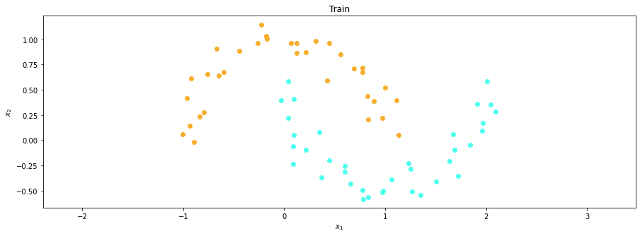

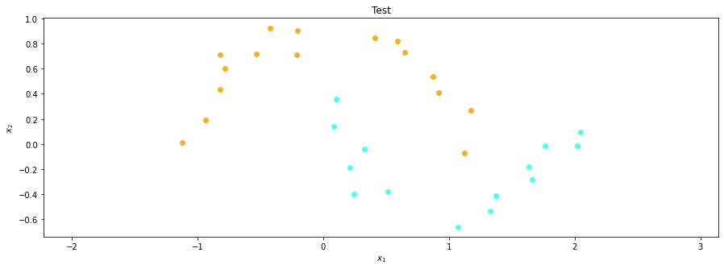

```python
from sklearn.datasets import make_moons
from sklearn.model_selection import train_test_split
from sklearn.svm import SVC

x, y = make_moons(noise=1e-1, random_state=seed)
y[y != 1] = -1

x_tr, x_te, y_tr, y_te = train_test_split(x, y, test_size=0.3, random_state=seed)

plot_dataset_clas(x_tr, y_tr)
plt.title('Train'); plt.show()
plot_dataset_clas(x_te, y_te)
plt.title('Test'); plt.show()
```

* Train an SVC model over the training data (`x_tr`, `y_tr`), using both the `SVC` class of `sklearn` and the implemented `MySVC` class. * Predict using the previous two models over the test data (`x_te`, `y_te`). * Compare that both classes provide the same outputs (in terms of the decision function and of the predicted class), describing the obtained results. If needed, reduce the default stopping tolerance and/or increase the default maximum number of iterations.

In the following cell we have developed a comparisson between the two SVMs. We can see the support vector indexes, as well as the acuracy and the F1-score, both in test. Finally, we plot the training dataset we both SVMs in order to compare how they split the different classes.

```
My SVM's support indexes (36): [ 0  1  3  6  8 12 15 16 18 19 20 24 26 27 29 30 31 32 33 35 37 39 42 43
 44 45 47 50 52 53 55 57 62 64 66 69]
Sklearn SVM's support indexes (25): [ 1  3  8 19 24 26 27 35 37 39 55 66  2  6  9 20 31 43 44 50 52 53 57 62
 69]

My SVM accuracy (in test): 0.9333333333333333
Sklearn SVM accuracy (in test): 0.9666666666666667

My SVM F1-score (in test): 0.9285714285714286
Sklearn SVM F1-score (in test): 0.9655172413793104

SKlearn's SVM:
```

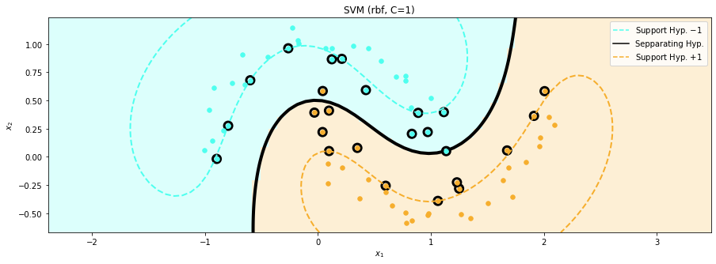

```
My SVM:
```

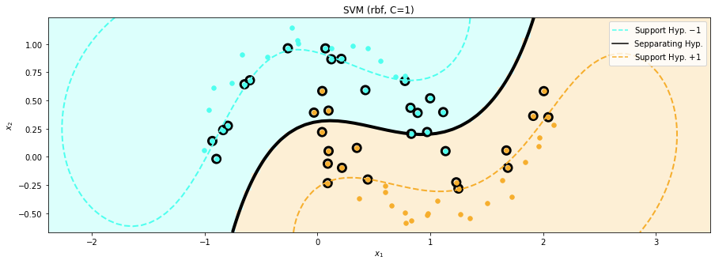

```python
from sklearn.metrics import accuracy_score, f1_score

def compare_svcs(x_tr, y_tr, x_te, y_te, C=1, gamma='scale', kernel='rbf', tol=0.0001, print_all=True):
    # Model definition
    model_my = MySVC(C=C, gamma=gamma, tol=tol, kernel=kernel)
    model_sk = SVC(C=C, gamma=gamma, tol=tol, kernel=kernel)

    # Training of the models.
    model_my.fit(x_tr, y_tr)
    model_sk.fit(x_tr, y_tr)

    # Predictions computations.
    y_predicted_my = model_my.predict(x_te)
    y_predicted_sk = model_sk.predict(x_te)

    if print_all:
        # Metrics computations.
        print('My SVM\'s support indexes ({}): {}'.format(len(model_my.support_), model_my.support_))
        print('Sklearn SVM\'s support indexes ({}): {} \n'.format(len(model_sk.support_), model_sk.support_))

        if kernel == 'linear':
            print('My SVM\'s primal coefficients: {}'.format(model_my.coef_))
            print('Sklearn SVM\'s primal coefficients: {} \n'.format(model_sk.coef_))

        # Comparative of the predicted scores.
        print('My SVM accuracy (in test): {}'.format(accuracy_score(y_te, y_predicted_my)))
        print('Sklearn SVM accuracy (in test): {} \n'.format(accuracy_score(y_te, y_predicted_sk)))
        print('My SVM F1-score (in test): {}'.format(f1_score(y_te, y_predicted_my)))
        print('Sklearn SVM F1-score (in test): {} \n'.format(f1_score(y_te, y_predicted_sk)))

    # Comparative of the predicted classes.
    plot_slack = kernel == 'linear'
    print('SKlearn\'s SVM:')
    plot_svc(x_tr, y_tr, model_sk, plot_slack=plot_slack)
    plt.show()
    print('My SVM:')
    plot_svc(x_tr, y_tr, model_my, plot_slack=plot_slack)
    plt.show()

compare_svcs(x_tr, y_tr, x_te, y_te, kernel='rbf', C=1)
```

As we can see, using the default hyperparameter ( $C$, $\epsilon$, `kernel`) values for both models already results in very high accuracies in both train and test sets.

Apart form the previous discussions, we can observe how our SVM splits the classes with high confidence. In the next and last experiment we aim to study how the regularization parameter `C` affects the SVMs.

We carry out an experiment in which we vary the $C$ value in the range $1,2,\dots,40$ and see how the model performs with each of the values of this hyperparameter.

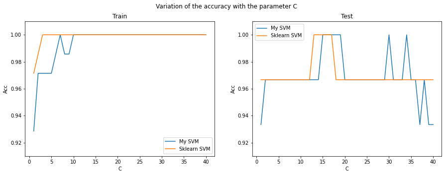

```python
def compare_svcs_plot_accuracies(x_tr, y_tr, x_te, y_te, Cs=[1], gamma='scale', kernel='rbf', tol=0.0001, print_all=True):

    # Declare vectors
    my_svm_accs = {'train':[],'test':[]}
    sk_svm_accs = {'train':[],'test':[]}

    for C in Cs:

        # Model definition and fit
        model_my = MySVC(C=C, gamma=gamma, tol=tol, kernel=kernel).fit(x_tr,y_tr)
        model_sk = SVC(C=C, gamma=gamma, tol=tol, kernel=kernel).fit(x_tr,y_tr)

        # Predict over the set and append to vectors
        my_svm_accs['train'].append(accuracy_score(model_my.predict(x_tr),y_tr))
        my_svm_accs['test'].append(accuracy_score(model_my.predict(x_te),y_te))

        sk_svm_accs['train'].append(accuracy_score(model_sk.predict(x_tr),y_tr))
        sk_svm_accs['test'].append(accuracy_score(model_sk.predict(x_te),y_te))

    if print_all:
        # Metrics print.
        print("The accuracies in the training set obtained for each different C for each model are:")
        print('My SVM\'s: {}'.format(my_svm_accs['train']))
        print('Sklearn SVM\'s: {} \n'.format(sk_svm_accs['train']))

        print("The accuracies in the test set obtained for each different C for each model are:")
        print('My SVM\'s: {}'.format(my_svm_accs['test']))
        print('Sklearn SVM\'s: {} \n'.format(sk_svm_accs['test']))

    # Comparative of the predicted classes.

    fig, (ax1, ax2) = plt.subplots(1, 2)
    fig.suptitle('Variation of the accuracy with the parameter C')

    ax1.set_ylim(0.91,1.01)
    ax2.set_ylim(0.91,1.01)

    ax1.plot(Cs, my_svm_accs['train'],label="My SVM")
    ax1.plot(Cs, sk_svm_accs['train'],label="Sklearn SVM")
    ax1.set_title("Train")
    ax1.legend(loc="lower right")


    ax2.plot(Cs, my_svm_accs['test'],label="My SVM")
    ax2.plot(Cs, sk_svm_accs['test'],label="Sklearn SVM")
    ax2.set_title("Test")
    ax2.legend(loc="upper left")


    ax1.set(xlabel='C',ylabel='Acc')
    ax2.set(xlabel='C',ylabel='Acc')
    plt.show()

compare_svcs_plot_accuracies(x_tr, y_tr, x_te, y_te,Cs = np.arange(1,41), kernel='rbf',print_all = False)
```

As we can see, when we increase the value of $C$ both models (SKlearn and ours) overfit the data (as we could expect) and classify all the points correctly. The graph for the test set shows that the behaviour is somewhat similar to one in the training set. We see some oscilations in the SMO's performance, which may be happening because of the randomness of this algorithm.

The following cell displays a gif varying the value of `C` for both our SVM and Sklearn's, from `1` to `40`.

```python
from matplotlib.animation import FuncAnimation
from celluloid import Camera
matplotlib.rc('figure', figsize=(20, 10))

def plot_animation(x_tr, y_tr, Cs=np.arange(1, 41)):
    fig, ax = plt.subplots(2)
    camera = Camera(fig)

    models_my = [
        MySVC(C=C).fit(x_tr, y_tr)
        for C in Cs
    ]
    models_sk = [
        SVC(C=C).fit(x_tr, y_tr)
        for C in Cs
    ]

    lims1, lims2 = None, None
    for i in range(len(models_my)):
        lims1 = plot_svc_animation_frame(x_tr, y_tr, ax[0], models_my[i], lims1,
            subtitle='My SVM ({})'.format(models_my[i].kernel))
        lims2 = plot_svc_animation_frame(x_tr, y_tr, ax[1], models_sk[i], lims2,
            subtitle='Sklearn\'s SVM ({})'.format(models_sk[i].kernel))
        ax[0].text(-0.1, 1.5, 'Comparisson with C={}'.format(models_sk[i].C), fontsize=20)
        camera.snap()

    animation = camera.animate()
    animation.save('SVC.gif', writer='imagemagick')
    plt.close()

plot_animation(x_tr, y_tr)
matplotlib.rc('figure', figsize=(10, 5))
```

[figure not shown]

In the GIF we can visually appretiate the differences that the previous graph showed. First of all, it is worth remarking that our update algorithm has some randomness in the election of the coefficients to update. That might be one of the reasons why two trainings of our SVM with really similar `C` values may vary form each other.

Additionally, we may appreciate (as we did in the previous graph) how Sklearn's SVM converges to its found optimum with `C` around $20$, staying in such optimum for the rest of the gif, while our convergence is much slower and weaker.

In order to improve our algorithm time-wise convergence we tried to better choose the next pair of coefficients $(\alpha_i, \alpha_j)$ to update. This leads us to the study of the [SMO algorithm](https://en.wikipedia.org/wiki/Sequential_minimal_optimization) and the [Karash-Kuhn-Tucker conditions](https://en.wikipedia.org/wiki/Karush%E2%80%93Kuhn%E2%80%93Tucker_conditions) for the coefficients. An optimal heuristic would consist of picking a pair of coefficients that violates the KKT conditions.

We finally decided that this was too out of scope for this practical assingment and didn't implement it.

## Understanding the SVM

* Considering the model created with the `MySVC` class: * Extract the list of **support vectors**, explaining the followed approach. * Extract the list of **training points bad and well classified**, explaining the followed approach. * Extract the list of **training points that lie over the supporting hyperplanes**. * Extract the list of **training points located on the wrong side of the supporting hyperplanes, but that are well classified**. * What are the conditions over the dual coefficients $\alpha_i$ that characterize the previous lists (if any)?

In the following cells we will display the different required outputs and graph the SVM highlighting the proper points. Let us start by plotting the **support vectors** surrounded by black circles in the following cell. They were computed by checking which alphas where greater than zero, and saving those indexes (in `model.support_`) to afterwards obtain the support vectors, saved in `model.support_vectors_`. We have kept the same notation that Sklearn uses for this type of model attributes so we plot our's and Sklearn's indistinguishably.

```
Support vectors:
[[ 1.68792426 -0.0981035 ]
 [-0.7952664   0.2746645 ]
 [ 0.9720389   0.21902698]
 [ 0.09841814  0.05019174]
 [ 0.42448524  0.59130712]
 [ 2.04744488  0.35091483]
 [ 0.82483944  0.43424825]
 [ 0.44598685 -0.20238606]
 [ 0.88775478  0.38926482]
 [ 1.23082636 -0.22735139]
 [ 1.115151    0.39583904]
 [ 0.12278879  0.8649236 ]
 [ 1.13567114  0.04975262]
 [ 0.21729751 -0.09860236]
 [-0.8367634   0.23609495]
 [ 1.67526518  0.05558455]
 [ 0.09103819 -0.06146458]
 [ 0.21104358  0.86864391]
 [-0.59960441  0.67856403]
 [ 0.12547372  0.96538716]
 [-0.26285754  0.96232495]
 [ 0.9989572   0.51851166]
 [ 0.0423632   0.58312272]
 [-0.03147581  0.39140976]
 [ 0.77585618  0.67232884]
 [-0.93271959  0.13940703]
 [ 1.25022826 -0.2826266 ]
 [ 2.00729148  0.58188871]
 [ 0.04062784  0.21890576]
 [ 0.83174596  0.20326404]
 [ 1.91345677  0.3625312 ]
 [ 0.09781582  0.4090848 ]
 [-0.6473039   0.64284721]
 [-0.89675203 -0.01943427]
 [ 0.34875151  0.07811214]]
```

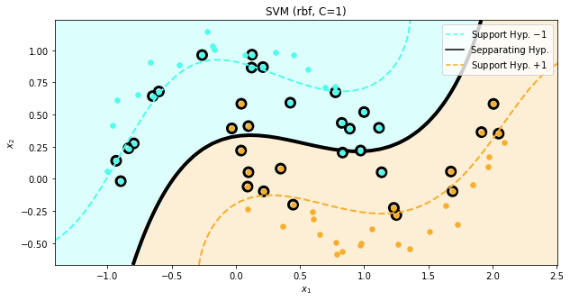

```python
def show_support_vectors(x_tr, y_tr, x_te, y_te, C=1, gamma='scale', kernel='rbf', tol=0.0001):
    # Model definition and training
    model = MySVC(C=C, gamma=gamma, tol=tol, kernel=kernel)
    model.fit(x_tr, y_tr)

    # Show the support vectors
    print('Support vectors: \n{}'.format(model.support_vectors_))

    #Plot
    plot_svc(x_tr, y_tr, model)

model = show_support_vectors(x_tr, y_tr, x_te, y_te)
```

In the following cell we see the **correctly and incorrectly classified training points** surrrounded by green and red circles respectively. These are computed by predicting the labels for the training points and comparing the result with the original labels.

```
Bad classified training points:
[[ 1.13567114  0.04975262]
 [ 0.0423632   0.58312272]
 [-0.03147581  0.39140976]
 [ 0.83174596  0.20326404]
 [ 0.09781582  0.4090848 ]]
```

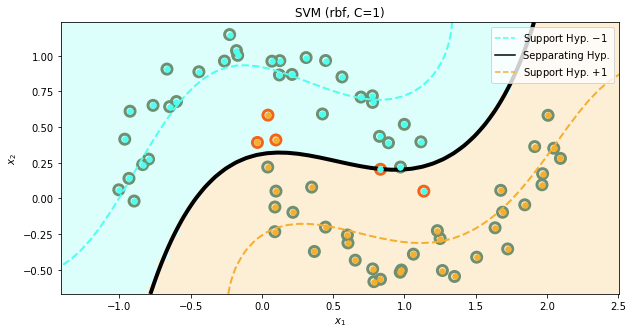

```python
def highlight_points(points, color):
    plt.scatter(points[:, 0],
                points[:, 1],
                s=100, linewidth=3, facecolors="none", edgecolors=color)

def show_classified_points(x_tr, y_tr, x_te, y_te, C=1, gamma='scale', kernel='rbf', tol=0.0001):
    # Model definition, training and prediction
    model = MySVC(C=C, gamma=gamma, tol=tol, kernel=kernel)
    model.fit(x_tr, y_tr)
    y_predicted = model.predict(x_tr)

    # Compute the bad and well classified training points
    hits = np.array([ orig == pred for orig, pred in zip(y_tr, y_predicted)])
    print('Bad classified training points: \n{}'.format(x_tr[~hits]))

    # Plot
    plot_svc(x_tr, y_tr, model, plot_support_vectors=False)
    highlight_points(x_tr[hits], '#6F8F72')
    highlight_points(x_tr[~hits], '#F26419')

show_classified_points(x_tr, y_tr, x_te, y_te)
```

```
Points over the supporting hyperplanes:
[ 0  2  4  5  7  9 10 11 13 14 16 17 18 21 22 23 25 28 33 34 36 38 40 41
 46 48 49 51 54 56 58 59 60 61 63 64 65 67 68]
```

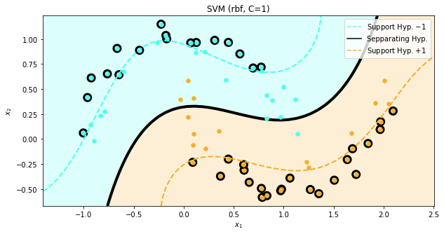

```python
def show_points_overs_supporting_planes(x_tr, y_tr, x_te, y_te, C=1, gamma='scale', kernel='rbf', tol=0.0001):
    # Model definition, training and prediction
    model = MySVC(C=C, gamma=gamma, tol=tol, kernel=kernel)
    model.fit(x_tr, y_tr)

    # Compute the bad and well classified training points
    over_indexes = np.array([ i for i, a in enumerate(model.a) if a == 0])
    print('Points over the supporting hyperplanes: \n{}'.format(over_indexes))

    # Plot
    plot_svc(x_tr, y_tr, model, plot_support_vectors=False)
    highlight_points(x_tr[over_indexes], 'k')

show_points_overs_supporting_planes(x_tr, y_tr, x_te, y_te)
```

In the following cell we plot **points located on the wrong side of the supporting hyperplanes, but that are well classified** surrounded by a black circles. As it was previously explained, these are points that fullfill two conditions: their alpha is greater than `0` (equivalent to being on the wrong side of the supporting hyperplane, since these are the support vectors), and having a correct prediction.

We may compute these points by intersecting the indexes of the support vectors and the correctly classified points.

```
Points :
[ 1  3  6  8 12 15 16 19 20 24 26 29 30 31 32 35 37 42 45 47 50 52 53 55
 57 61 64 65 66 69]
```

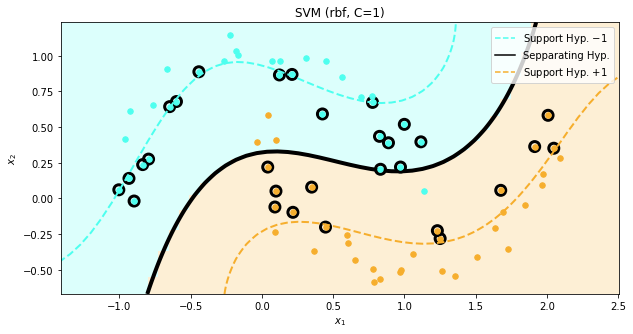

```python
def show_final_points(x_tr, y_tr, x_te, y_te, C=1, gamma='scale', kernel='rbf', tol=0.0001):
    # Model definition, training and prediction
    model = MySVC(C=C, gamma=gamma, tol=tol, kernel=kernel)
    model.fit(x_tr, y_tr)
    y_predicted = model.predict(x_tr)

    # Compute the bad and well classified training points
    bad_classified = np.array([ i for i, (orig, pred) in enumerate(zip(y_tr, y_predicted)) if orig == pred])
    result = np.intersect1d(bad_classified, model.support_)
    print('Points : \n{}'.format(result))

    # Plot
    plot_svc(x_tr, y_tr, model, plot_support_vectors=False)
    highlight_points(x_tr[result], 'k')

show_final_points(x_tr, y_tr, x_te, y_te)
```

# Extra 1: Linear Kernel

We have implemented our SVM so it supports different type of kernels. In particular, if `kernel=linear`,a linear kernel is used. In the following cell we find a comparisson between Sklear's linear kernel and our SVM with linear kernel.

```
My SVM's support indexes (29): [ 3  6  8 12 15 16 19 24 27 29 30 32 33 42 43 44 45 47 49 52 53 54 55 57
 60 62 65 66 69]
Sklearn SVM's support indexes (27): [ 3  8 15 19 24 27 42 45 47 49 55 60 65 66  6 12 16 29 32 33 43 44 52 53
 57 62 69]

My SVM's primal coefficients: [[ 0.82726503 -2.15942729]]
Sklearn SVM's primal coefficients: [[ 0.77096307 -2.19842572]]

My SVM accuracy (in test): 0.8666666666666667
Sklearn SVM accuracy (in test): 0.8666666666666667

My SVM F1-score (in test): 0.8571428571428571
Sklearn SVM F1-score (in test): 0.8571428571428571

SKlearn's SVM:
```

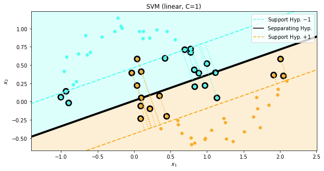

```
My SVM:
```

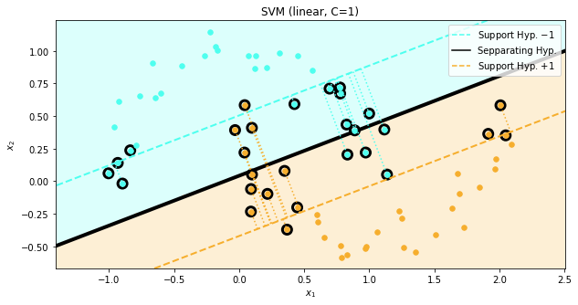

```python
compare_svcs(x_tr, y_tr, x_te, y_te, kernel='linear')
```

# Extra 2: Polynomic kernels

In addition to the linear kernel, our SVM accepts in the `kernel` parameter any function. For instance, we may try polynomial kernels. That is:

$$ K(x,y) = (x^T*y)^d $$

where `d` is the degree, a given parameter. In the following cells we train train two SVMs with polynomial kernel, with degrees 3 and 4 respectively.

```
My SVM accuracy: 0.9333333333333333
My SVM F1-score: 0.9333333333333333
```

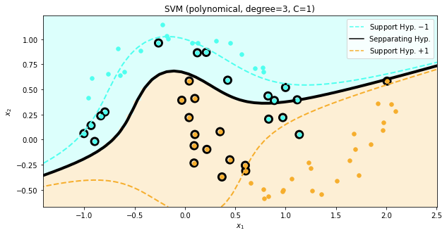

```
My SVM accuracy: 0.7666666666666667
My SVM F1-score: 0.8
```

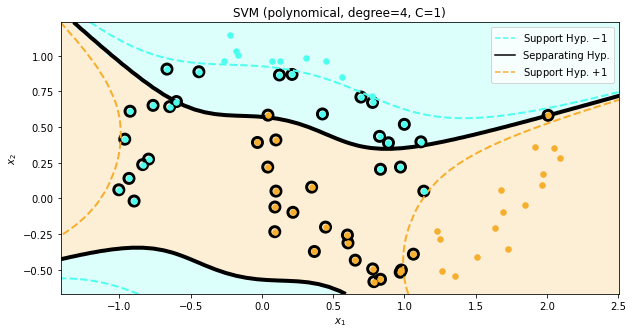

```python
def plot_polynomic_kernel(x_tr, y_tr, x_te, y_te, degree=3, C=1):
    kernel = lambda X, Y: linear_kernel(X, Y)**degree

    model = MySVC(kernel=kernel, C=C)
    model.fit(x_tr, y_tr)
    y_predicted = model.predict(x_te)

    print('My SVM accuracy: {}'.format(accuracy_score(y_te, y_predicted)))
    print('My SVM F1-score: {} \n'.format(f1_score(y_te, y_predicted)))
    plot_svc(x_tr, y_tr, model)
    plt.title('SVM (polynomical, degree={}, C={})'.format(degree, C))
    plt.show()

plot_polynomic_kernel(x_tr, y_tr, x_te, y_te, 3, C=1)
plot_polynomic_kernel(x_tr, y_tr, x_te, y_te, 4, C=1)
```

# Future lines of work

- Study if a decreasing value of `C` with the number of iteration (like reducing the temperature in simulated annealing) would translate into a faster convergence. This comes from the hypothesis that we are sometimes cropping the new values of $(\alpha_i, \alpha_j)$ by a lot in the SMO algorithm, based on the value of `C`. We hadn't implemented this line of work either because in need a different way of updating the coefficients to maintaing the problem restrictions.
- Study how to better choose the next pair of coefficients $(\alpha_i, \alpha_j)$. That is, the pair that violates the [Karash-Kuhn-Tucker conditions](https://en.wikipedia.org/wiki/Karush%E2%80%93Kuhn%E2%80%93Tucker_conditions).
- Try different inicialization methods for the $\alpha$ coefficients, keeping in mind the restrictions of our problem..
- Try different types of kernels.